# Main

Saeid Abolfazli (PhD)

May 17, 2016

Lets read the data into R

```r
file <- file.path("data","census.csv")
census <- read.table(file,sep=",", header=TRUE)
str(census)
```

```
## 'data.frame':    31978 obs. of  13 variables:
##  $ age          : int  39 50 38 53 28 37 49 52 31 42 ...
##  $ workclass    : Factor w/ 9 levels " ?"," Federal-gov",..: 8 7 5 5 5 5 5 7 5 5 ...
##  $ education    : Factor w/ 16 levels " 10th"," 11th",..: 10 10 12 2 10 13 7 12 13 10 ...
##  $ maritalstatus: Factor w/ 7 levels " Divorced"," Married-AF-spouse",..: 5 3 1 3 3 3 4 3 5 3 ...
##  $ occupation   : Factor w/ 15 levels " ?"," Adm-clerical",..: 2 5 7 7 11 5 9 5 11 5 ...
##  $ relationship : Factor w/ 6 levels " Husband"," Not-in-family",..: 2 1 2 1 6 6 2 1 2 1 ...
##  $ race         : Factor w/ 5 levels " Amer-Indian-Eskimo",..: 5 5 5 3 3 5 3 5 5 5 ...
##  $ sex          : Factor w/ 2 levels " Female"," Male": 2 2 2 2 1 1 1 2 1 2 ...
##  $ capitalgain  : int  2174 0 0 0 0 0 0 0 14084 5178 ...
##  $ capitalloss  : int  0 0 0 0 0 0 0 0 0 0 ...
##  $ hoursperweek : int  40 13 40 40 40 40 16 45 50 40 ...
##  $ nativecountry: Factor w/ 41 levels " Cambodia"," Canada",..: 39 39 39 39 5 39 23 39 39 39 ...
##  $ over50k      : Factor w/ 2 levels " <=50K"," >50K": 1 1 1 1 1 1 1 2 2 2 ...
```

### Problem 1.1 - A Logistic Regression Model

Let’s begin by building a logistic regression model to predict whether an individual’s earnings are above $50,000 (the variable “over50k”) using all of the other variables as independent variables. First, read the dataset census.csv into R.

Then, split the data randomly into a training set and a testing set, setting the seed to 2000 before creating the split. Split the data so that the training set contains 60% of the observations, while the testing set contains 40% of the observations.

```r
library("lubripack")
lubripack("caTools")
```

```
##
## Bellow Packages Successfully Installed:
##
## caTools
##    TRUE
```

```r
set.seed(2000)
index <- sample.split(census$over50k, 0.6)
train <- census[index,]
test <- census[!index,]
```

Next, build a logistic regression model to predict the dependent variable “over50k”, using all of the other variables in the dataset as independent variables. Use the training set to build the model.

```r
censusLogit <- glm(over50k~., data = train, family = "binomial")
```

```
## Warning: glm.fit: fitted probabilities numerically 0 or 1 occurred
```

```r
summary(censusLogit)
```

```
##
## Call:
## glm(formula = over50k ~ ., family = "binomial", data = train)
##
## Deviance Residuals:
##     Min       1Q   Median       3Q      Max
## -5.1065  -0.5037  -0.1804  -0.0008   3.3383
##
## Coefficients: (1 not defined because of singularities)
##                                            Estimate Std. Error z value
## (Intercept)                              -8.658e+00  1.379e+00  -6.279
## age                                       2.548e-02  2.139e-03  11.916
## workclass Federal-gov                     1.105e+00  2.014e-01   5.489
## workclass Local-gov                       3.675e-01  1.821e-01   2.018
## workclass Never-worked                   -1.283e+01  8.453e+02  -0.015
## workclass Private                         6.012e-01  1.626e-01   3.698
## workclass Self-emp-inc                    7.575e-01  1.950e-01   3.884
## workclass Self-emp-not-inc                1.855e-01  1.774e-01   1.046
## workclass State-gov                       4.012e-01  1.961e-01   2.046
## workclass Without-pay                    -1.395e+01  6.597e+02  -0.021
## education 11th                            2.225e-01  2.867e-01   0.776
## education 12th                            6.380e-01  3.597e-01   1.774
## education 1st-4th                        -7.075e-01  7.760e-01  -0.912
## education 5th-6th                        -3.170e-01  4.880e-01  -0.650
## education 7th-8th                        -3.498e-01  3.126e-01  -1.119
## education 9th                            -1.258e-01  3.539e-01  -0.355
## education Assoc-acdm                      1.602e+00  2.427e-01   6.601
## education Assoc-voc                       1.541e+00  2.368e-01   6.506
## education Bachelors                       2.177e+00  2.218e-01   9.817
## education Doctorate                       2.761e+00  2.893e-01   9.544
## education HS-grad                         1.006e+00  2.169e-01   4.638
## education Masters                         2.421e+00  2.353e-01  10.289
## education Preschool                      -2.237e+01  6.864e+02  -0.033
## education Prof-school                     2.938e+00  2.753e-01  10.672
## education Some-college                    1.365e+00  2.195e-01   6.219
## maritalstatus Married-AF-spouse           2.540e+00  7.145e-01   3.555
## maritalstatus Married-civ-spouse          2.458e+00  3.573e-01   6.880
## maritalstatus Married-spouse-absent      -9.486e-02  3.204e-01  -0.296
## maritalstatus Never-married              -4.515e-01  1.139e-01  -3.962
## maritalstatus Separated                   3.609e-02  1.984e-01   0.182
```

[output cut: 162 more lines]

```
## nativecountry Thailand                   0.329678
## nativecountry Trinadad&Tobago            0.434105
## nativecountry United-States              0.946020
## nativecountry Vietnam                    0.507799
## nativecountry Yugoslavia                 0.394874
## ---
## Signif. codes:  0 '***' 0.001 '**' 0.01 '*' 0.05 '.' 0.1 ' ' 1
##
## (Dispersion parameter for binomial family taken to be 1)
##
##     Null deviance: 21175  on 19186  degrees of freedom
## Residual deviance: 12104  on 19090  degrees of freedom
## AIC: 12298
##
## Number of Fisher Scoring iterations: 15
```

Which variables are significant, or have factors that are significant? (Use 0.1 as your significance threshold, so variables with a period or dot in the stars column should be counted too. You might see a warning message here - you can ignore it and proceed. This message is a warning that we might be overfitting our model to the training set.) Select all that apply.

### Problem 1.2 - A Logistic Regression Model

What is the accuracy of the model on the testing set? Use a threshold of 0.5. (You might see a warning message when you make predictions on the test set - you can safely ignore it.)

```r
Pred <- predict(censusLogit, newdata = test, type="response")
```

```
## Warning in predict.lm(object, newdata, se.fit, scale = 1, type =
## ifelse(type == : prediction from a rank-deficient fit may be misleading
```

```r
table(test$over50k,Pred >= 0.5)
```

```
##
##          FALSE TRUE
##    <=50K  9051  662
##    >50K   1190 1888
```

```r
Pred
```

[output not shown]

[output cut: 5063 more lines]

[output not shown]

```r
(1888+9051)/sum(table(test$over50k,Pred >= 0.5))
```

```
## [1] 0.8552107
```

### Problem 1.3 - A Logistic Regression Model

What is the baseline accuracy for the testing set?

```r
table(train$over50k)
```

```
##
##  <=50K   >50K
##  14570   4617
```

```r
14570/(14570+4617)
```

```
## [1] 0.7593683
```

```r
table(test$over50k)
```

```
##
##  <=50K   >50K
##   9713   3078
```

```r
9713/(9713+3078)
```

```
## [1] 0.7593621
```

### Problem 1.4 - A Logistic Regression Model

What is the area-under-the-curve (AUC) for this model on the test set?

```r
lubripack("ROCR")
```

```
##
## Bellow Packages Successfully Installed:
##
## ROCR
## TRUE
```

```r
RPCRPred <- prediction(Pred,test$over50k)
ROCRPerf <- performance(RPCRPred,"auc")
ROCRPerf
```

```
## An object of class "performance"
## Slot "x.name":
## [1] "None"
##
## Slot "y.name":
## [1] "Area under the ROC curve"
##
## Slot "alpha.name":
## [1] "none"
##
## Slot "x.values":
## list()
##
## Slot "y.values":
## [[1]]
## [1] 0.9061598
##
##
## Slot "alpha.values":
## list()
```

### Problem 2.1 - A CART Model

```r
lubripack("rpart","rpart.plot")
```

```
##
## Bellow Packages Successfully Installed:
##
##      rpart rpart.plot
##       TRUE       TRUE
```

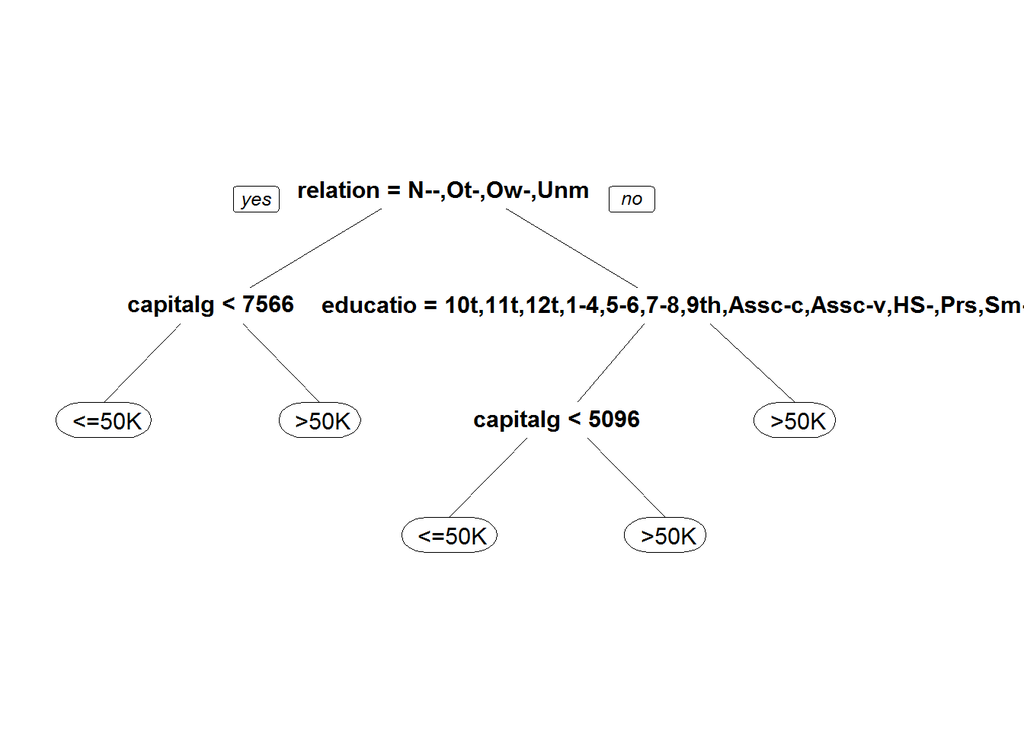

```r
CensusCART <- rpart(over50k~., data= train, method = "class")
prp(CensusCART)
```

How many splits does the tree have in total?

### Problem 2.2 - A CART Model

Which variable does the tree split on at the first level (the very first split of the tree)?

Which variables does the tree split on at the second level (immediately after the first split of the tree)? Select all that apply.

**Answer:** education, capitalgain

### Problem 2.4 - A CART Model

What is the accuracy of the model on the testing set? Use a threshold of 0.5. (You can either add the argument type=“class”, or generate probabilities and use a threshold of 0.5 like in logistic regression.)

```r
Pred <- predict(CensusCART, newdata = test)[,2]
table(test$over50k,Pred >=0.5)
```

```
##
##          FALSE TRUE
##    <=50K  9243  470
##    >50K   1482 1596
```

```r
accuracr <- (9243+1596)/sum(table(test$over50k,Pred >=0.5))
```

### Problem 2.5 - A CART Model

Let us now consider the ROC curve and AUC for the CART model on the test set. You will need to get predicted probabilities for the observations in the test set to build the ROC curve and compute the AUC. Remember that you can do this by removing the type=“class” argument when making predictions, and taking the second column of the resulting object.

```r
lubripack("ROCR")
```

```
##
## Bellow Packages Successfully Installed:
##
## ROCR
## TRUE
```

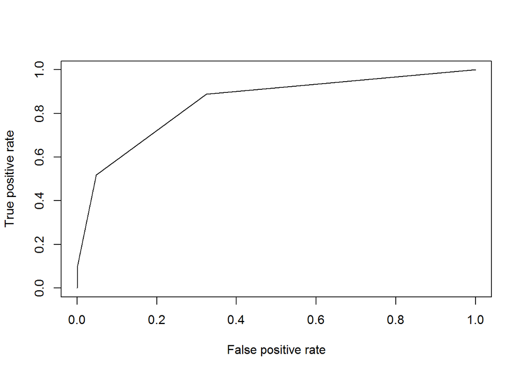

```r
ROCRPred <- prediction(Pred,test$over50k)

ROCRPerf <- performance(ROCRPred,"tpr","fpr")
plot(ROCRPerf)
```

Plot the ROC curve for the CART model you have estimated. Observe that compared to the logistic regression ROC curve, the CART ROC curve is less smooth than the logistic regression ROC curve. Which of the following explanations for this behavior is most correct? (HINT: Think about what the ROC curve is plotting and what changing the threshold does.)

**Answer:** The probabilities from the CART model take only a handful of values (five, one for each end bucket/leaf of the tree); the changes in the ROC curve correspond to setting the threshold to one of those values.

### Problem 2.6 - A CART Model

What is the AUC of the CART model on the test set?

```r
ROCRPerf <- performance(ROCRPred,"auc")
```

[output not shown]

### Problem 3.1 - A Random Forest Model

Before building a random forest model, we’ll down-sample our training set. While some modern personal computers can build a random forest model on the entire training set, others might run out of memory when trying to train the model since random forests is much more computationally intensive than CART or Logistic Regression. For this reason, before continuing we will define a new training set to be used when building our random forest model, that contains 2000 randomly selected obervations from the original training set. Do this by running the following commands in your R console (assuming your training set is called “train”):

```r
set.seed(1)

trainSmall = train[sample(nrow(train), 2000), ]
```

Let us now build a random forest model to predict “over50k”, using the dataset “trainSmall” as the data used to build the model. Set the seed to 1 again right before building the model, and use all of the other variables in the dataset as independent variables. (If you get an error that random forest “can not handle categorical predictors with more than 32 categories”, re-build the model without the nativecountry variable as one of the independent variables.)

```r
lubripack("randomForest")
```

```
##
## Bellow Packages Successfully Installed:
##
## randomForest
##         TRUE
```

```r
set.seed(1)
censusForest <- randomForest(over50k~., data = trainSmall)
summary(censusForest)
```

```
##                 Length Class  Mode
## call               3   -none- call
## type               1   -none- character
## predicted       2000   factor numeric
## err.rate        1500   -none- numeric
## confusion          6   -none- numeric
## votes           4000   matrix numeric
## oob.times       2000   -none- numeric
## classes            2   -none- character
## importance        12   -none- numeric
## importanceSD       0   -none- NULL
## localImportance    0   -none- NULL
## proximity          0   -none- NULL
## ntree              1   -none- numeric
## mtry               1   -none- numeric
## forest            14   -none- list
## y               2000   factor numeric
## test               0   -none- NULL
## inbag              0   -none- NULL
## terms              3   terms  call
```

Then, make predictions using this model on the entire test set. What is the accuracy of the model on the test set, using a threshold of 0.5? (Remember that you don’t need a “type” argument when making predictions with a random forest model if you want to use a threshold of 0.5. Also, note that your accuracy might be different from the one reported here, since random forest models can still differ depending on your operating system, even when the random seed is set. )

```r
Pred_Forest_Test <- predict(censusForest, newdata = test)
lubripack("dplyr")
```

```
##
## Bellow Packages Successfully Installed:
##
## dplyr
##  TRUE
```

```r
(table(test$over50k, Pred_Forest_Test) %>% diag %>% sum %>% as.numeric) /  sum(table(test$over50k, Pred_Forest_Test))
```

```
## [1] 0.8348839
```

### Problem 3.2 - A Random Forest Model

As we discussed in lecture, random forest models work by building a large collection of trees. As a result, we lose some of the interpretability that comes with CART in terms of seeing how predictions are made and which variables are important. However, we can still compute metrics that give us insight into which variables are important.

One metric that we can look at is the number of times, aggregated over all of the trees in the random forest model, that a certain variable is selected for a split. To view this metric, run the following lines of R code (replace “MODEL” with the name of your random forest model):

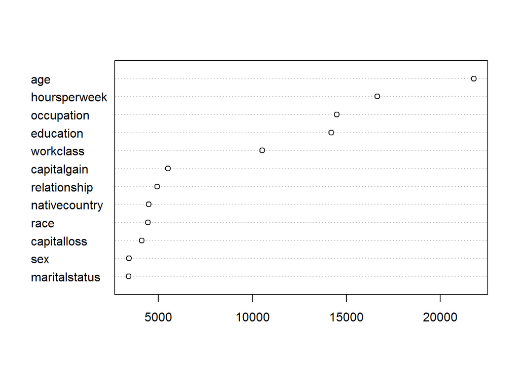

```r
vu = varUsed(censusForest, count=TRUE)
vusorted = sort(vu, decreasing = FALSE, index.return = TRUE)
dotchart(vusorted$x, names(censusForest$forest$xlevels[vusorted$ix]))
```

This code produces a chart that for each variable measures the number of times that variable was selected for splitting (the value on the x-axis). Which of the following variables is the most important in terms of the number of splits?

Which one of the following variables is the most important in terms of mean reduction in impurity?

(1 point possible) We now conclude our study of this data set by looking at how CART behaves with different choices of its parameters.

cartGrid = expand.grid( .cp = seq(0.002,0.1,0.002))

Which value of cp does the train function recommend?

(2 points possible) Fit a CART model to the training data using this value of cp. What is the prediction accuracy on the test set?